# A3: Incarceration

### Introduction

This assignment focuses on the pertinent issue of incarceration in America. Compared to other countries, the United States incarcerates people at an alarmingly high rate. Furthermore, unjust trials and implicit (and explicit) bias have led Black individuals to make up a disproportionate number of these people. Previously, data on incarceration trends was limited only to local areas or to the country as a whole, and local trends were not compared or examined on a country-wide level to uncover possible patterns in this data. The Vera project has done incredible work collecting and corroborating incarceration data. In this analysis, my goal is to expand on the work of the Vera project by comparing the rate of incarceration among states in cities (which generally swing more left politically) and rural areas (which tend to be more conservative) in an effort to determine how political stance (and how populated an area is) correlates to incarceration rate.

### Summary Information

Using the values from the dataset, I determined that the overall average rate of incarceration (number of people in prison per 100,000 people) for all races in all areas was 528.6894546. The overall average rate among Black people was 2785.1461093 - over five times higher than the rate among all races. This trend can be seen in all different urbanicities individually, too. In rural areas, the average incarceration rate for all races is 539.788958, compared to 2919.4779989. in urban areas, the rates are 727.4432509 and 2531.4654112, respectively. Interestingly, the incarceration rate for all races was higher in cities, but the rate among black people was lower. It’s possible that this is because of the general social, cultural, and political sentiments in rural area which may lead to differing biases and unjust detainment of black individuals.

### The Dataset

$Who$ $collected$ $the$ $data?$

The data was collected by a team of researchers at Vera, which is a program fighting for prison reform and aiming to end the unjust incarceration of people of color and other underrepresented groups.

$How$ $was$ $the$ $data$ $collected$ $or$ $generated?$

The data was collected using data from the Census of Jails, the Annual Survey of Jails, and the National Corrections Reporting Program. Data from these three sources were merged into one large dataset that contains information on incarceration across the country at a county level.

$Why$ $was$ $the$ $data$ $collected?$

The data was collected in an effort to provide a more detailed look at incarceration trends across the country. Previously, data had only been available at the state level, which fails to capture the nuances of incarceration trends more locally. Additionally, the broadness of previous datasets made it difficult to apply to the local level. This dataset helps fill in those gaps.

$How$ $many$ $observations$ $(rows)$ $are$ $in$ $your$ $data?$

There are 153,811 rows in this dataset.

$How$ $many$ $features$ $(columns)$ $are$ $in$ $the$ $data?$

There are 23 columns.

$What,$ $if$ $any,$ $ethical$ $questions$ $or$ $questions$ $of$ $power$ $do$ $you$ $need$ $to$ $consider$ $when$ $working$ $with$ $this$ $data?$

This dataset does an excellent job of upholding ethical principles. given that the data is entirely anonymous and its collection likely did not harm anyone involved, I don’t see any ethical issues that can be called into question. As for questions of power, I believe it’s important to acknowledge who initially collected the data and how their biases could have interfered.

$What$ $are$ $possible$ $limitations$ $or$ $problems$ $with$ $this$ $data?$ (at least 200 words)

One major limitation that I forsee when using this data is that there are quite a few spaces that are entered as “N/A”. This is expecially true for the rural areas, due to the fact that their population is smaller and therefore they are less likely to have people of certain, less populous, demographics. Along these lines, one other issue I can see coming into play with this dataset is the difference in the sheer amount of data between urban areas and small or mid-size cities and rural areas. Because large cities have significantly more people, they are data is less likely to be skewed by outliers and more likely to portray an accurate incarceration rate. On the contrary, because of the small population of small cities and rural areas, the data is easily skewed because a one person counts for a much larger portion of the population. In addition to the challenge of differing sample sizes, another problem with this dataset is that there is no information on the overall demographics of a city or town. This is problematic because if a city has a larger percentage of black people, then they will naturally incarcerate more black people as this population makes up much of the demographic. However, this information will be inaccurately portrayed as the city simply having a much higher incarceration rate for reasons other than demographics.

### Trends Over Time Chart

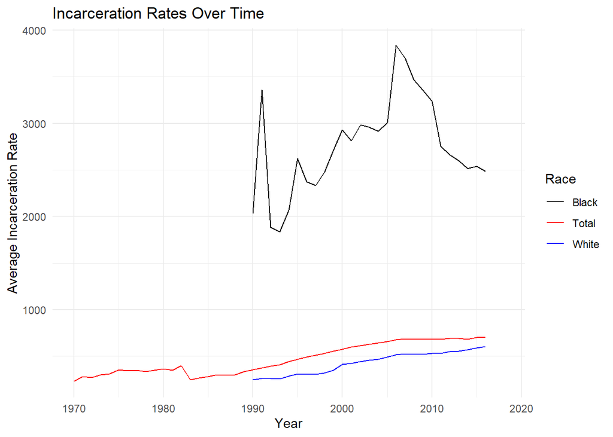

This graph depicts the average incarceration rate of different groups over time. The red line shows the average rate of imprisonment agross all groups in all areas, the blue line denotes this rate for white people, and the black like denotes this rate among black people. I chose to compare black, white and total average incarceration rate with the goal of having a clear view how incarceration rates have changed relative to each other over time. This graph shows that over time, the average incarceration rate for black people has consistently been much higher than that of white people. Additionally, this rate has increased over time for both groups, though there is much more variation in the rate for black individuals. Interestingly, the graph indicates a sharp decline in black incarceration rates between ~2008 and 2017. I wonder if this decrease was related to the fact that the US had a liberal president during this time or possibly that our president during this period was also black. However, even with this noticeable decline in Black incarceration rates recently, Black people are still put in prison at an alarmingly high rate compared to other groups.

### Variable Comparison Chart

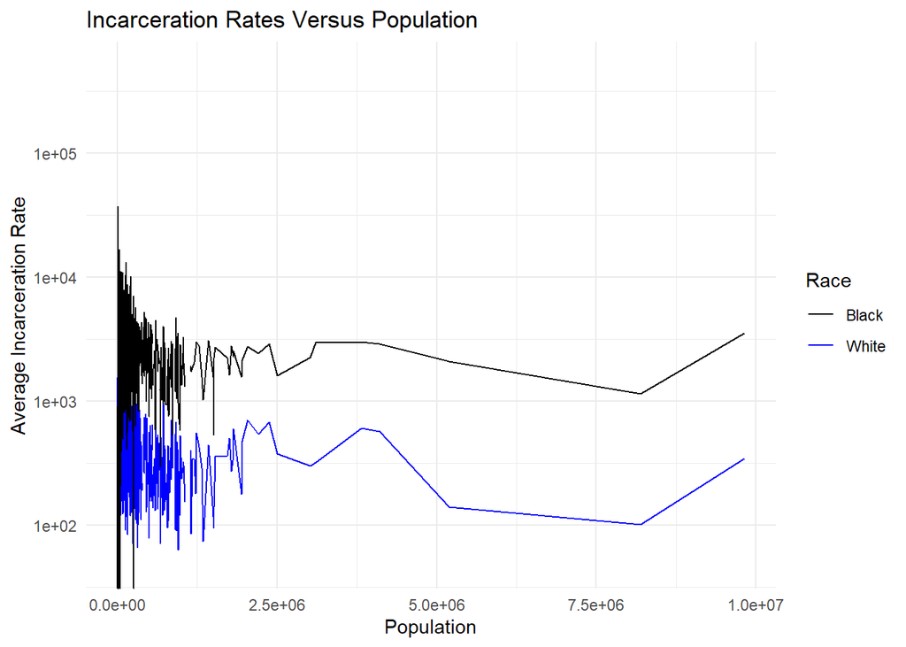

[figure not shown]

This chart depicts a map of the US in which the color of each state is representative of the average incarceration rate - number of people imprisoned per 100,000 residents - of Black individuals across that state. Examining the graph, it appears that midwestern states and southern states generally have slightly higher incarceration rates, as indicated by the deeper shade of blue in those areas. This corroborates my prediction that there is a correlation between a state’s general political standing and its incarceration rate, as these states tend to sway towards the more conservative end - maps on recent elections support this. Along the same lines, more liberal states such as california, Washington, and the Northeast tended to have lower incarceration rates, as indicated by their lighter color on the map. Interestingly, Nebraska had the highest incarceration rate and deepest shade of blue on the map by a large margin. Given its generally conservative political standing, its high rate is relatively unsurprising,, but the large margin between it and the rest of the states could be the result of an outlier in the data.